# Getting Around Without a Car in Philadelphia

- Show All Code
- Hide All Code
- View Source

Assignment 4 · Building Features, Watching What Happens

Author

Thomas Hagos

I wanted to look at where Philadelphia households are living without a vehicle. This matters because getting to work, a doctor’s appointment, or the grocery store can look very different depending on the transportation options around you. My question is whether neighborhood characteristics can help predict the share of households with no vehicle, and whether adding information about place makes that prediction better.

## Part 0: Setup

```r
library(tidyverse)
library(tidycensus)
library(sf)
library(caret)
assignment_dir <- dirname(normalizePath(knitr::current_input(dir = TRUE)))
knitr::opts_knit$set(root.dir = assignment_dir)
options(scipen = 999)
theme_set(theme_minimal(base_size = 12))
fmt <- function(x) formatC(x, digits = 2, format = "f")
```

I use the 2019–2023 ACS five-year estimates and two Philadelphia open-data layers restricted to 2023. The raw downloads are saved in `data/` so rerunning the analysis uses the same records. The ACS estimates describe a five-year period; the incidents describe one year within that period. This is a retrospective prediction exercise, rather than a claim that all predictors were available before 2019.

```r
ctrl <- trainControl(method = "cv", number = 10)
cv_rmse <- function(formula, data) {
  df <- if (inherits(data, "sf")) st_drop_geometry(data) else data
  vars <- all.vars(formula)
  bad <- vars[sapply(vars, function(v) any(is.na(df[[v]])))]
  if (length(bad) > 0) {
    stop("These variables have NAs: ", paste(bad, collapse = ", "),
         ". Fill them or choose another variable (Rule 1: don't drop rows).")
  }
  set.seed(5080)
  fit <- train(formula, data = df, method = "lm", trControl = ctrl)
  fit$results$RMSE
}
model_log <- tibble(model = character(), added = character(),
                    cv_rmse = numeric(), notes = character())
formulas <- list()
log_model <- function(id, formula, added, notes) {
  formulas[[id]] <<- formula
  model_log <<- add_row(model_log, model = id, added = added,
                       cv_rmse = cv_rmse(formula, tracts), notes = notes)
}
```

## Part 1: Choosing and checking the outcome

### Pulling the ACS data

The outcome is `B08201_002 / B08201_001 × 100`: households with no vehicle divided by all households. My four baseline predictors are median household income, the percentage of occupied units that are rented, the percentage of adults 25 and older with at least a bachelor’s degree, and the percentage of residents 65 and older. These describe resources, housing tenure, education, and age without using vehicle ownership or commuting mode as a predictor.

```r
acs_vars <- c(
  total_pop = "B01003_001", households = "B08201_001",
  no_vehicle = "B08201_002", income = "B19013_001",
  occupied = "B25003_001", renter = "B25003_003",
  edu_total = "B15003_001", ba = "B15003_022", ma = "B15003_023",
  prof = "B15003_024", phd = "B15003_025", age_total = "B01001_001",
  male65a = "B01001_020", male65b = "B01001_021", male65c = "B01001_022",
  male65d = "B01001_023", male65e = "B01001_024", male65f = "B01001_025",
  female65a = "B01001_044", female65b = "B01001_045", female65c = "B01001_046",
  female65d = "B01001_047", female65e = "B01001_048", female65f = "B01001_049"
)
if (!file.exists("data/acs_2023.rds")) {
  philly_tracts <- get_acs(geography = "tract", state = "PA",
    county = "Philadelphia", variables = acs_vars, year = 2023,
    output = "wide", geometry = TRUE) %>% st_transform(2272)
  saveRDS(philly_tracts, "data/acs_2023.rds")
}
philly_tracts <- readRDS("data/acs_2023.rds")
```

### Building the outcome and its uncertainty

```r
philly_tracts <- philly_tracts %>%
  mutate(
    y = if_else(householdsE > 0, no_vehicleE / householdsE * 100, NA_real_),
    y_moe = if_else(householdsE > 0,
      moe_prop(no_vehicleE, householdsE, no_vehicleM, householdsM) * 100,
      NA_real_),
    y_cv = if_else(y > 0, (y_moe / 1.645) / y * 100, NA_real_),
    income_10k = if_else(incomeE > 0, incomeE / 10000, NA_real_),
    pct_renter = if_else(occupiedE > 0, renterE / occupiedE * 100, NA_real_),
    pct_ba = if_else(edu_totalE > 0,
      (baE + maE + profE + phdE) / edu_totalE * 100, NA_real_),
    pct_65 = if_else(age_totalE > 0,
      (male65aE + male65bE + male65cE + male65dE + male65eE + male65fE +
       female65aE + female65bE + female65cE + female65dE + female65eE + female65fE) /
       age_totalE * 100, NA_real_),
    reliability = case_when(
      !is.finite(y_cv) ~ "Undefined", y_cv < 12 ~ "High",
      y_cv <= 40 ~ "Moderate", TRUE ~ "Low")
  )
philly_tracts %>% st_drop_geometry() %>% count(reliability) %>% knitr::kable()
```

| reliability | n |
| --- | --- |
| High | 29 |
| Low | 45 |
| Moderate | 313 |
| Undefined | 21 |

```r
summary(philly_tracts$y_cv)
```

```
   Min. 1st Qu.  Median    Mean 3rd Qu.    Max.     NAs
  3.572  17.201  23.397  26.254  31.875 182.123      21
```

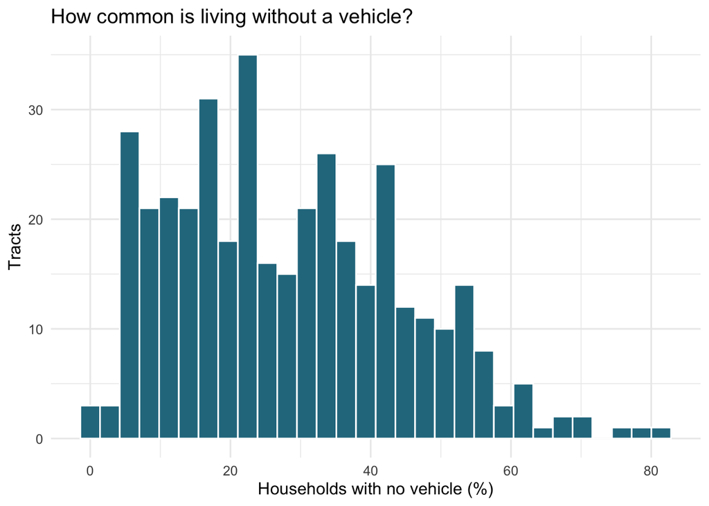

```r
ggplot(philly_tracts, aes(y)) + geom_histogram(bins = 30, fill = "#28788e", color = "white") +
  labs(x = "Households with no vehicle (%)", y = "Tracts",
       title = "How common is living without a vehicle?")
```

There are 20 tracts without a calculable outcome. Of the 387 tracts with a defined coefficient of variation, 45 have low reliability, or 11.63%. I kept this outcome because that share is below the assignment’s one-third guideline, while still recognizing that the tract estimates carry uncertainty. A transportation agency could use predictions to help identify places where households may depend heavily on alternatives to driving.

### Filtering once

```r
tracts <- philly_tracts %>%
  filter(total_popE > 0, is.finite(y), is.finite(income_10k),
         is.finite(pct_renter), is.finite(pct_ba), is.finite(pct_65))
fixed_ids <- tracts$GEOID
excluded <- philly_tracts %>% st_drop_geometry() %>%
  filter(!GEOID %in% fixed_ids) %>%
  select(GEOID, NAME, total_popE, householdsE, incomeE)
knitr::kable(excluded, caption = "Tracts excluded before any models are compared")
```

Tracts excluded before any models are compared

| GEOID | NAME | total_popE | householdsE | incomeE |
| --- | --- | --- | --- | --- |
| 42101016500 | Census Tract 165; Philadelphia County; Pennsylvania | 2165 | 978 | NA |
| 42101980902 | Census Tract 9809.02; Philadelphia County; Pennsylvania | 0 | 0 | NA |
| 42101980800 | Census Tract 9808; Philadelphia County; Pennsylvania | 0 | 0 | NA |
| 42101028500 | Census Tract 285; Philadelphia County; Pennsylvania | 2625 | 1081 | NA |
| 42101036901 | Census Tract 369.01; Philadelphia County; Pennsylvania | 49 | 0 | NA |
| 42101014800 | Census Tract 148; Philadelphia County; Pennsylvania | 892 | 525 | NA |
| 42101027700 | Census Tract 277; Philadelphia County; Pennsylvania | 5489 | 2448 | NA |
| 42101030100 | Census Tract 301; Philadelphia County; Pennsylvania | 6446 | 2642 | NA |
| 42101980500 | Census Tract 9805; Philadelphia County; Pennsylvania | 0 | 0 | NA |
| 42101980600 | Census Tract 9806; Philadelphia County; Pennsylvania | 0 | 0 | NA |
| 42101989100 | Census Tract 9891; Philadelphia County; Pennsylvania | 1240 | 0 | NA |
| 42101989300 | Census Tract 9893; Philadelphia County; Pennsylvania | 160 | 0 | NA |
| 42101980001 | Census Tract 9800.01; Philadelphia County; Pennsylvania | 0 | 0 | NA |
| 42101980002 | Census Tract 9800.02; Philadelphia County; Pennsylvania | 0 | 0 | NA |
| 42101980906 | Census Tract 9809.06; Philadelphia County; Pennsylvania | 0 | 0 | NA |
| 42101020500 | Census Tract 205; Philadelphia County; Pennsylvania | 3383 | 1663 | NA |
| 42101980200 | Census Tract 9802; Philadelphia County; Pennsylvania | 396 | 13 | NA |
| 42101989200 | Census Tract 9892; Philadelphia County; Pennsylvania | 0 | 0 | NA |
| 42101980901 | Census Tract 9809.01; Philadelphia County; Pennsylvania | 0 | 0 | NA |
| 42101980003 | Census Tract 9800.03; Philadelphia County; Pennsylvania | 0 | 0 | NA |
| 42101980701 | Census Tract 9807.01; Philadelphia County; Pennsylvania | 0 | 0 | NA |
| 42101980903 | Census Tract 9809.03; Philadelphia County; Pennsylvania | 0 | 0 | NA |
| 42101980905 | Census Tract 9809.05; Philadelphia County; Pennsylvania | 0 | 0 | NA |
| 42101980400 | Census Tract 9804; Philadelphia County; Pennsylvania | 0 | 0 | NA |
| 42101980702 | Census Tract 9807.02; Philadelphia County; Pennsylvania | 0 | 0 | NA |
| 42101980300 | Census Tract 9803; Philadelphia County; Pennsylvania | 0 | 0 | NA |
| 42101980904 | Census Tract 9809.04; Philadelphia County; Pennsylvania | 0 | 0 | NA |

I started with 408 tracts and kept 381, losing 27. Of the excluded tracts, 17 had no residents and three had residents but no households, consistent with places dominated by nonresidential land or group quarters. Seven others had households but no reported median income. The table identifies the exact tracts; I would need land-use or institutional boundaries to name their uses confidently. A tract without households cannot have a household vehicle-availability rate; a populated tract can also lack a usable baseline predictor. I do not replace either situation with a made-up outcome. Every model below uses the same remaining tracts in the same order.

## Part 2: The baseline model

### Looking before fitting

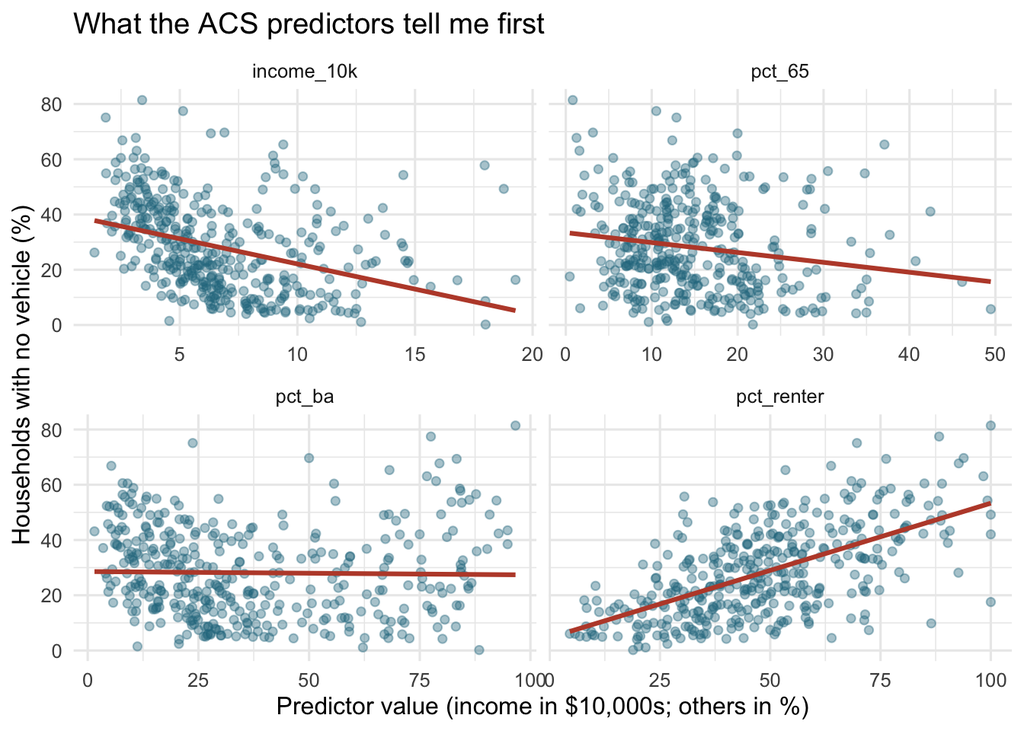

```r
tracts %>% st_drop_geometry() %>%
  select(y, income_10k, pct_renter, pct_ba, pct_65) %>%
  pivot_longer(-y, names_to = "predictor", values_to = "value") %>%
  ggplot(aes(value, y)) + geom_point(alpha = .4, color = "#28788e") +
  geom_smooth(method = "lm", se = FALSE, color = "#bc4b36") +
  facet_wrap(~predictor, scales = "free_x") +
  labs(x = "Predictor value (income in $10,000s; others in %)",
       y = "Households with no vehicle (%)", title = "What the ACS predictors tell me first")
```

```r
f1 <- y ~ income_10k + pct_renter + pct_ba + pct_65
m1 <- lm(f1, data = tracts)
summary(m1)
```

```
Call:
lm(formula = f1, data = tracts)

Residuals:
    Min      1Q  Median      3Q     Max
-35.047  -8.326  -1.067   8.026  45.088

Coefficients:
            Estimate Std. Error t value             Pr(>|t|)
(Intercept) 19.71430    3.31839   5.941        0.00000000646 ***
income_10k  -1.82396    0.38288  -4.764        0.00000271790 ***
pct_renter   0.37746    0.04256   8.869 < 0.0000000000000002 ***
pct_ba       0.10396    0.05031   2.066               0.0395 *
pct_65      -0.09622    0.08235  -1.168               0.2434
---
Signif. codes:  0 '***' 0.001 '**' 0.01 '*' 0.05 '.' 0.1 ' ' 1

Residual standard error: 12.37 on 376 degrees of freedom
Multiple R-squared:  0.4301,    Adjusted R-squared:  0.424
F-statistic: 70.93 on 4 and 376 DF,  p-value: < 0.00000000000000022
```

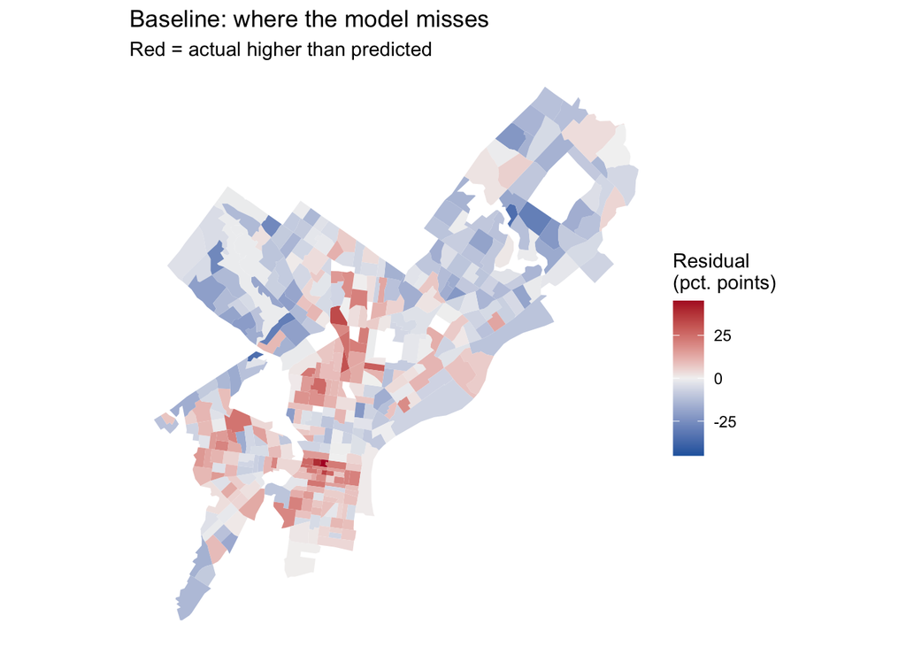

```r
log_model("m1", f1, "ACS baseline", "Four predictors; outcome stays in percentage points")
tracts$resid_m1 <- residuals(m1)
map_resid <- function(variable, title, limit = max(abs(tracts$resid_m1))) {
  ggplot(tracts) + geom_sf(aes(fill = .data[[variable]]), color = NA) +
    scale_fill_gradient2(low = "#2166ac", mid = "grey95", high = "#b2182b",
                         midpoint = 0, limits = c(-limit, limit)) +
    theme_void() + labs(title = title, subtitle = "Red = actual higher than predicted",
                        fill = "Residual\n(pct. points)")
}
map_resid("resid_m1", "Baseline: where the model misses")
```

On tracts it has not seen, the baseline model misses by about **12.47 percentage points**. This is the mean of the ten held-out fold RMSEs, using the assignment’s helper. It measures errors in the predicted percentage of households, rather than the number of households.

The errors have a geographic pattern. I see red tracts grouped through parts of North and South Philadelphia, while much of the Northeast is blue. The baseline is missing something about location: it underpredicts vehicle-free households in some areas and overpredicts them in others. That led me to test neighborhood-condition layers, along with distance from the city center. The maps motivate these choices, but they do not tell me what causes vehicle ownership.

## Part 3: Two historical open-data layers

I use residential burglary incidents and shooting-victim records from 2023. These are two separate spatial layers: the first records reported burglary incidents, while the second records victims, so several shooting-victim records can refer to the same incident. I expect them to capture aspects of neighborhood conditions that income, age, education, and rental tenure miss. They are imperfect proxies for the environment around households, rather than direct measures of transportation access.

Both queries filter dates on the server before downloading. I avoid today’s live bike-share station feed because it would introduce locations that might not have existed by 2023. These layers also have limits: reporting and policing affect what appears in the records, and generalized locations can affect which side of a tract boundary a record falls on.

```r
carto_get <- function(sql) {
  url <- paste0("https://phl.carto.com/api/v2/sql?format=GeoJSON&q=",
                URLencode(sql, reserved = TRUE))
  st_read(url, quiet = TRUE)
}
burglary_sql <- "SELECT the_geom, dispatch_date, text_general_code
  FROM incidents_part1_part2
  WHERE dispatch_date >= '2023-01-01' AND dispatch_date < '2024-01-01'
  AND text_general_code = 'Burglary Residential'"
shooting_sql <- "SELECT the_geom, date_ FROM shootings
  WHERE date_ >= '2023-01-01' AND date_ < '2024-01-01'"
if (!file.exists("data/burglary_2023.rds"))
  saveRDS(carto_get(burglary_sql), "data/burglary_2023.rds")
if (!file.exists("data/shootings_2023.rds"))
  saveRDS(carto_get(shooting_sql), "data/shootings_2023.rds")
burglary_raw <- readRDS("data/burglary_2023.rds")
shooting_raw <- readRDS("data/shootings_2023.rds")
clean_points <- function(x) x %>%
  filter(!st_is_empty(.)) %>% st_transform(2272)
burglary <- clean_points(burglary_raw)
shootings <- clean_points(shooting_raw)
geometry_audit <- tibble(
  layer = c("Residential burglary", "Shooting victims"),
  downloaded = c(nrow(burglary_raw), nrow(shooting_raw)),
  missing_geometry = c(sum(st_is_empty(burglary_raw)), sum(st_is_empty(shooting_raw))),
  retained = c(nrow(burglary), nrow(shootings)))
knitr::kable(geometry_audit)
```

| layer | downloaded | missing_geometry | retained |
| --- | --- | --- | --- |
| Residential burglary | 3800 | 119 | 3681 |
| Shooting victims | 1673 | 1 | 1672 |

## Part 4: Building spatial features

I first try raw burglary counts, then add burglary density, shooting-victim density, distance to the nearest shooting-victim location, and distance to City Hall. Counts capture volume, densities account for tract area, and distances describe location. Distances are straight-line miles from a point inside each tract, so they do not measure a resident’s actual travel route. EPSG 2272 uses feet; I divide distances by 5,280 and areas by 27,878,400.

```r
tract_pts <- st_point_on_surface(tracts)
city_hall <- st_sfc(st_point(c(-75.1636, 39.9526)), crs = 4326) %>% st_transform(2272)
nearest_idx <- st_nearest_feature(tract_pts, shootings)
tracts <- tracts %>% mutate(
  area_sqmi = as.numeric(st_area(.)) / 27878400,
  n_burglary = lengths(st_intersects(., burglary)),
  n_shooting = lengths(st_intersects(., shootings)),
  burglary_density = n_burglary / area_sqmi,
  shooting_density = n_shooting / area_sqmi,
  dist_shooting_mi = as.numeric(st_distance(tract_pts, shootings[nearest_idx, ],
                                          by_element = TRUE)) / 5280,
  dist_ch_mi = as.numeric(st_distance(tract_pts, city_hall)) / 5280)
# A zero count is a genuine zero; it is never converted to missing.
stopifnot(identical(tracts$GEOID, fixed_ids), all(tracts$area_sqmi > 0))
tracts %>% st_drop_geometry() %>%
  select(n_burglary, burglary_density, shooting_density, dist_shooting_mi, dist_ch_mi) %>% summary()
```

```
   n_burglary     burglary_density shooting_density  dist_shooting_mi
 Min.   : 0.000   Min.   :  0.00   Min.   :  0.000   Min.   :0.001737
 1st Qu.: 4.000   1st Qu.: 13.59   1st Qu.:  0.000   1st Qu.:0.088819
 Median : 7.000   Median : 33.54   Median :  9.743   Median :0.163686
 Mean   : 9.446   Mean   : 52.94   Mean   : 22.150   Mean   :0.260858
 3rd Qu.:13.000   3rd Qu.: 69.96   3rd Qu.: 28.321   3rd Qu.:0.304050
 Max.   :48.000   Max.   :367.98   Max.   :311.871   Max.   :2.421646
   dist_ch_mi
 Min.   : 0.1729
 1st Qu.: 2.3091
 Median : 4.3983
 Mean   : 5.0474
 3rd Qu.: 7.1631
 Max.   :14.7878
```

```r
# Audit intersection assignments: boundary points can touch more than one tract.
audit_assignments <- function(x) {
  n <- lengths(st_intersects(x, tracts))
  tibble(outside_model_tracts = sum(n == 0), assigned_once = sum(n == 1),
         touches_multiple_tracts = sum(n > 1))
}
bind_rows(burglary = audit_assignments(burglary),
          shooting_victims = audit_assignments(shootings), .id = "layer") %>% knitr::kable()
```

| layer | outside_model_tracts | assigned_once | touches_multiple_tracts |
| --- | --- | --- | --- |
| burglary | 82 | 3599 | 0 |
| shooting_victims | 61 | 1611 | 0 |

The audit separates missing locations from points outside the retained model tracts. Points touching multiple tracts can contribute to more than one tract under the assignment’s intersection method; the table reports that issue instead of silently assuming every point has exactly one assignment.

```r
f2 <- update(f1, . ~ . + n_burglary)
log_model("m2", f2, "+ burglary count", "Raw volume")
f3 <- update(f2, . ~ . + burglary_density)
log_model("m3", f3, "+ burglary per square mile", "Density alongside count")
f4 <- update(f3, . ~ . + shooting_density)
log_model("m4", f4, "+ shooting victims per square mile", "Separate historical layer")
f5 <- update(f4, . ~ . + dist_shooting_mi)
log_model("m5", f5, "+ nearest shooting-victim distance", "Straight-line miles")
f6 <- update(f5, . ~ . + dist_ch_mi)
log_model("m6", f6, "+ City Hall distance", "Central location proxy")
spatial_log <- model_log %>% mutate(improvement = lag(cv_rmse) - cv_rmse)
knitr::kable(spatial_log, digits = 3)
```

| model | added | cv_rmse | notes | improvement |
| --- | --- | --- | --- | --- |
| m1 | ACS baseline | 12.469 | Four predictors; outcome stays in percentage points | NA |
| m2 | + burglary count | 12.118 | Raw volume | 0.351 |
| m3 | + burglary per square mile | 11.569 | Density alongside count | 0.549 |
| m4 | + shooting victims per square mile | 11.302 | Separate historical layer | 0.267 |
| m5 | + nearest shooting-victim distance | 10.782 | Straight-line miles | 0.519 |
| m6 | + City Hall distance | 9.864 | Central location proxy | 0.919 |

Distance to City Hall helped the most among the spatial additions: it lowered CV RMSE from 10.78 to 9.86 percentage points, a drop of about 0.92. Burglary density also helped, lowering it from 12.12 to 11.57, which shows why I should not rely only on raw counts. Shooting-victim density and nearest distance brought smaller improvements. Central location seems to capture differences that the demographic variables alone miss, although it could stand in for transit access, development patterns, parking, or other unmeasured conditions. These are improvements along this particular sequence; changing the order of additions could change which feature gets credit.

## Part 5: Letting the relationships bend

### Looking at the shapes

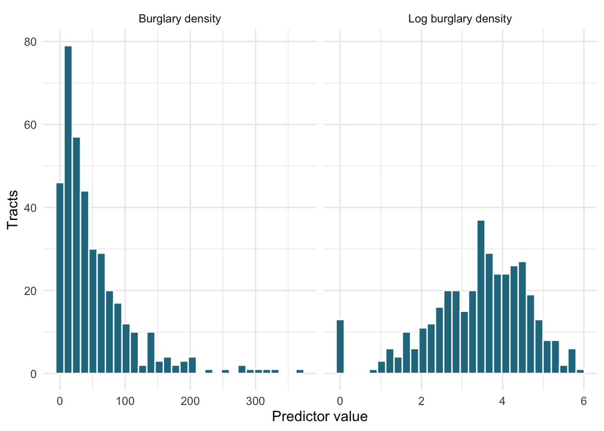

```r
tracts %>% st_drop_geometry() %>%
  transmute(`Burglary density` = burglary_density,
            `Log burglary density` = log1p(burglary_density)) %>%
  pivot_longer(everything(), names_to = "scale", values_to = "value") %>%
  ggplot(aes(value)) + geom_histogram(bins = 30, fill = "#28788e", color = "white") +
  facet_wrap(~scale, scales = "free_x") + labs(x = "Predictor value", y = "Tracts")
```

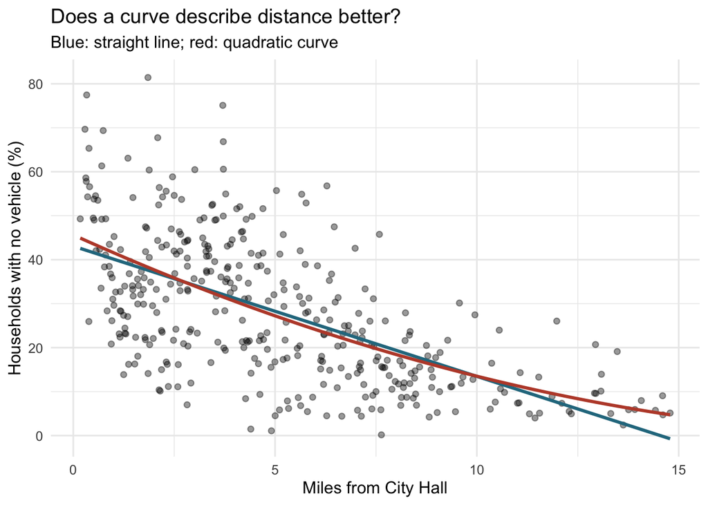

```r
ggplot(tracts, aes(dist_ch_mi, y)) + geom_point(alpha = .4) +
  geom_smooth(method = "lm", formula = y ~ x, se = FALSE, color = "#28788e") +
  geom_smooth(method = "lm", formula = y ~ x + I(x^2), se = FALSE, color = "#bc4b36") +
  labs(x = "Miles from City Hall", y = "Households with no vehicle (%)",
       title = "Does a curve describe distance better?",
       subtitle = "Blue: straight line; red: quadratic curve")
```

Burglary density has a long right tail, so I try `log1p()` to compress unusually large values while keeping zero-count tracts. The distance plot lets me compare a straight line with a curve before testing the squared term. I also try core, inner, and outer distance rings as a simpler way of representing central location. The rings are an alternative to continuous City Hall distance, rather than extra terms on top of it.

```r
tracts <- tracts %>% mutate(ring = factor(case_when(
  dist_ch_mi < 2 ~ "Core", dist_ch_mi < 5 ~ "Inner", TRUE ~ "Outer"),
  levels = c("Core", "Inner", "Outer")))
tracts %>% st_drop_geometry() %>% count(ring) %>% knitr::kable()
```

| ring | n |
| --- | --- |
| Core | 79 |
| Inner | 134 |
| Outer | 168 |

```r
stopifnot(all(table(tracts$ring) >= 20))
# Each transformation is compared with m6 to isolate its contribution.
f_log <- update(f6, . ~ . - burglary_density + log1p(burglary_density))
log_model("m_log", f_log, "Replace burglary density with log1p", "Compare with m6")
f_sq <- update(f6, . ~ . + I(dist_ch_mi^2))
log_model("m_sq", f_sq, "+ squared City Hall distance", "Retain the linear distance term")
f_cat <- update(f6, . ~ . - dist_ch_mi + ring)
log_model("m_cat", f_cat, "Replace City Hall distance with rings", "Core is the reference level")
m_cat <- lm(f_cat, data = tracts)
knitr::kable(model_log, digits = 3)
```

| model | added | cv_rmse | notes |
| --- | --- | --- | --- |
| m1 | ACS baseline | 12.469 | Four predictors; outcome stays in percentage points |
| m2 | + burglary count | 12.118 | Raw volume |
| m3 | + burglary per square mile | 11.569 | Density alongside count |
| m4 | + shooting victims per square mile | 11.302 | Separate historical layer |
| m5 | + nearest shooting-victim distance | 10.782 | Straight-line miles |
| m6 | + City Hall distance | 9.864 | Central location proxy |
| m_log | Replace burglary density with log1p | 10.048 | Compare with m6 |
| m_sq | + squared City Hall distance | 9.593 | Retain the linear distance term |
| m_cat | Replace City Hall distance with rings | 10.000 | Core is the reference level |

```r
summary(m_cat)
```

```
Call:
lm(formula = f_cat, data = tracts)

Residuals:
    Min      1Q  Median      3Q     Max
-26.801  -6.433  -0.638   5.593  35.649

Coefficients:
                  Estimate Std. Error t value             Pr(>|t|)
(Intercept)       32.57359    3.73496   8.721 < 0.0000000000000002 ***
income_10k        -1.68978    0.30721  -5.500   0.0000000707923861 ***
pct_renter         0.24434    0.03505   6.971   0.0000000000145189 ***
pct_ba             0.03400    0.04687   0.725              0.46870
pct_65             0.19266    0.07267   2.651              0.00836 **
n_burglary        -0.10592    0.11231  -0.943              0.34623
burglary_density   0.04520    0.01587   2.849              0.00463 **
shooting_density   0.06408    0.02000   3.203              0.00148 **
dist_shooting_mi  -6.00312    2.33108  -2.575              0.01040 *
ringInner         -9.06085    1.86458  -4.859   0.0000017417722755 ***
ringOuter        -16.06587    2.04528  -7.855   0.0000000000000438 ***
---
Signif. codes:  0 '***' 0.001 '**' 0.01 '*' 0.05 '.' 0.1 ' ' 1

Residual standard error: 9.76 on 370 degrees of freedom
Multiple R-squared:  0.6507,    Adjusted R-squared:  0.6412
F-statistic: 68.92 on 10 and 370 DF,  p-value: < 0.00000000000000022
```

The squared distance term helped the most. Compared with m6, it lowered CV RMSE from 9.86 to 9.59 percentage points. The log transformation went in the other direction, increasing RMSE to 10.05, even though it made the burglary-density distribution look less skewed. The distance rings also did worse than continuous distance, at 10.00. I found that useful: a cleaner-looking distribution or a simpler category does not automatically make a better predictor.

In the categorical model, the Inner coefficient is -9.06. Holding the other predictors constant, the predicted share of households with no vehicle is 9.06 percentage points lower in the Inner ring than in the **Core**, the reference group. These are broad distance groups, so they cannot capture every difference between neighborhoods within the same ring.

## Part 6: Choosing the final model

I choose the specification with the lowest cross-validated RMSE among the tested candidates. If a larger model does worse, its extra variables have not earned a place. This uses the same folds to compare several choices, so the winning score is a model-selection result; a separate holdout or nested cross-validation would give a less optimistic assessment of future performance. Random tract folds also allow nearby tracts in training and testing, which can make prediction across entirely new areas harder than this score suggests.

```r
winner <- model_log$model[which.min(model_log$cv_rmse)]
f_final <- formulas[[winner]]
m_final <- lm(f_final, data = tracts)
log_model("final", f_final, paste("Selected", winner), "Lowest mean CV RMSE among tested specifications")
summary(m_final)
```

```
Call:
lm(formula = f_final, data = tracts)

Residuals:
     Min       1Q   Median       3Q      Max
-25.7418  -5.9671  -0.5812   5.2369  30.4747

Coefficients:
                 Estimate Std. Error t value             Pr(>|t|)
(Intercept)      42.02000    4.04842  10.379 < 0.0000000000000002 ***
income_10k       -1.63027    0.29662  -5.496    0.000000072452028 ***
pct_renter        0.22950    0.03371   6.808    0.000000000040157 ***
pct_ba           -0.01834    0.04580  -0.400              0.68906
pct_65            0.18652    0.07065   2.640              0.00864 **
n_burglary       -0.16861    0.10611  -1.589              0.11292
burglary_density  0.03657    0.01543   2.370              0.01832 *
shooting_density  0.05664    0.01897   2.985              0.00302 **
dist_shooting_mi -2.35446    2.31906  -1.015              0.31064
dist_ch_mi       -4.91232    0.64063  -7.668    0.000000000000156 ***
I(dist_ch_mi^2)   0.20901    0.04246   4.922    0.000001291661175 ***
---
Signif. codes:  0 '***' 0.001 '**' 0.01 '*' 0.05 '.' 0.1 ' ' 1

Residual standard error: 9.346 on 370 degrees of freedom
Multiple R-squared:  0.6797,    Adjusted R-squared:  0.671
F-statistic:  78.5 on 10 and 370 DF,  p-value: < 0.00000000000000022
```

```r
tracts <- tracts %>% mutate(resid_final = residuals(m_final))
stopifnot(identical(tracts$GEOID, fixed_ids), nobs(m_final) == length(fixed_ids))
final_rmse <- tail(model_log$cv_rmse, 1)
improvement_pct <- 100 * (model_log$cv_rmse[1] - final_rmse) / model_log$cv_rmse[1]
knitr::kable(model_log, digits = 3, caption = "Complete model log; lower RMSE is better")
```

Complete model log; lower RMSE is better

| model | added | cv_rmse | notes |
| --- | --- | --- | --- |
| m1 | ACS baseline | 12.469 | Four predictors; outcome stays in percentage points |
| m2 | + burglary count | 12.118 | Raw volume |
| m3 | + burglary per square mile | 11.569 | Density alongside count |
| m4 | + shooting victims per square mile | 11.302 | Separate historical layer |
| m5 | + nearest shooting-victim distance | 10.782 | Straight-line miles |
| m6 | + City Hall distance | 9.864 | Central location proxy |
| m_log | Replace burglary density with log1p | 10.048 | Compare with m6 |
| m_sq | + squared City Hall distance | 9.593 | Retain the linear distance term |
| m_cat | Replace City Hall distance with rings | 10.000 | Core is the reference level |
| final | Selected m_sq | 9.593 | Lowest mean CV RMSE among tested specifications |

```r
write_csv(model_log, "model_log.csv")
write_csv(st_drop_geometry(tracts) %>%
  select(GEOID, NAME, y, y_moe, y_cv, reliability, resid_m1, resid_final),
  "tract_results.csv")
saveRDS(list(log = model_log, tracts = tracts, excluded = excluded,
             final = m_final, categorical = m_cat, winner = winner), "data/results.rds")
```

The final model is **m_sq**, with a cross-validated RMSE of **9.59 percentage points**. That is a **23.07% reduction** from the baseline’s 12.47 percentage points. The outcome stays on its original percentage scale throughout, so these scores are directly comparable. RMSE is a summary of squared errors, not a guarantee that every tract’s prediction will fall within this distance.

### Comparing the residual maps

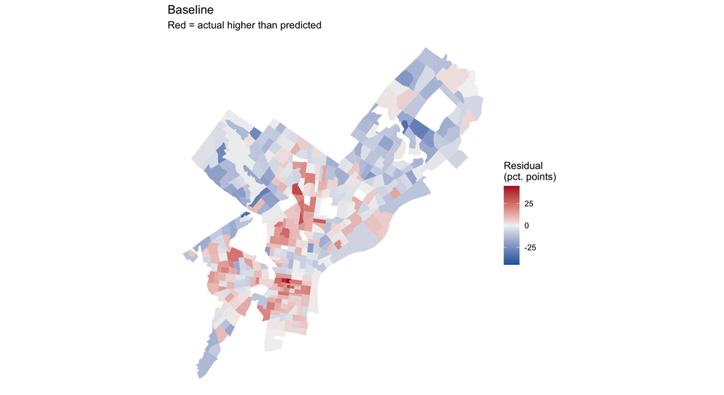

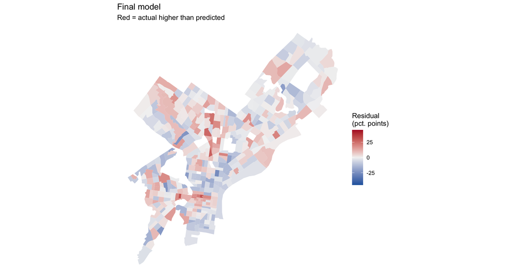

```r
common_limit <- max(abs(c(tracts$resid_m1, tracts$resid_final)))
map_resid("resid_m1", "Baseline", common_limit)
map_resid("resid_final", "Final model", common_limit)
```

Both maps use the same color limits. These are residuals from models fitted to all retained tracts, useful for seeing patterns, while the reported model scores come from held-out folds. Red means the model underpredicts the share of households with no vehicle; blue means it overpredicts it.

The strong red band in parts of South Philadelphia is lighter in the final map, and much of the broad blue pattern in the Northeast is less pronounced. Still, the errors have not disappeared: there are red pockets in North Philadelphia and near the center, along with blue pockets in the west. I would describe this as an improvement in the pattern, rather than a complete solution. Next, I would want historical SEPTA stop locations, service frequency, and access to jobs to see whether transportation access explains some of those remaining differences.

### Are the largest misses also the noisiest estimates?

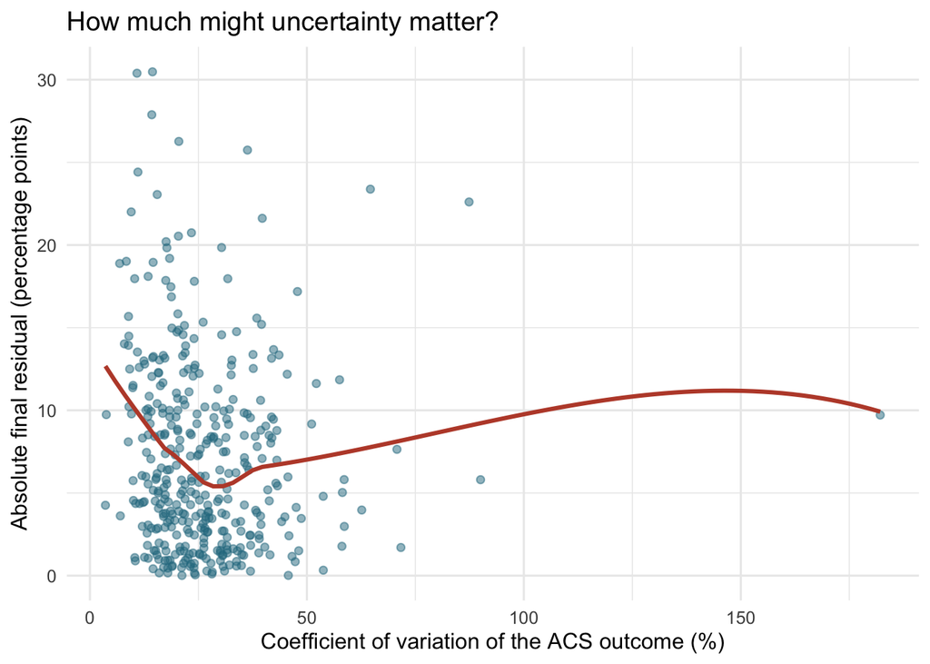

```r
fog <- tracts %>% st_drop_geometry() %>% filter(is.finite(y_cv))
ggplot(fog, aes(y_cv, abs(resid_final))) +
  geom_point(alpha = .5, color = "#28788e") + geom_smooth(se = FALSE, color = "#bc4b36") +
  labs(x = "Coefficient of variation of the ACS outcome (%)",
       y = "Absolute final residual (percentage points)",
       title = "How much might uncertainty matter?")
```

```r
fog_rho <- cor(fog$y_cv, abs(fog$resid_final), method = "spearman")
noise_summary <- fog %>% group_by(reliability) %>%
  summarise(tracts = n(), mean_abs_residual = mean(abs(resid_final)),
            median_outcome_se = median(y_moe / 1.645), .groups = "drop")
knitr::kable(noise_summary, digits = 2)
```

| reliability | tracts | mean_abs_residual | median_outcome_se |
| --- | --- | --- | --- |
| High | 28 | 11.61 | 5.11 |
| Low | 45 | 7.03 | 3.08 |
| Moderate | 308 | 6.75 | 5.80 |

I do not see a simple pattern where less reliable estimates always produce larger misses. The Spearman correlation between the outcome’s coefficient of variation and absolute residual is -0.15, and the average absolute residual is actually highest in the high-reliability group. The curve turns up again in the sparse right tail, so I would be careful about reading too much into that end of the plot. Survey noise may contribute to individual errors, but this comparison does not tell me what percentage of total error comes from noise. Relative uncertainty also depends on the size of the outcome: a small percentage can have a high coefficient of variation while its absolute uncertainty is modest.

## Part 7: Reflection

What stood out to me was how much location added after the Census variables were already in the model. Distance to City Hall gave the largest improvement among the spatial additions, reducing CV RMSE by about 0.92 percentage points. Adding its squared term helped further. That makes sense because being one mile farther from the center probably does not mean the same thing everywhere in the city. The final model’s CV RMSE was 9.59 percentage points, compared with 12.47 for the baseline, a reduction of about 23.1%.

The log transformation was the biggest disappointment. I expected compressing the long tail of burglary density to help, but its RMSE rose to 10.05. It reminded me that making a variable look better in a histogram is not enough. I need to check whether it improves predictions on tracts outside the training fold.

For a β̂ reading, a $10,000 increase in tract median household income is associated with about 1.63 percentage points fewer households without a vehicle, holding the other predictors constant; this observational association does not establish that raising income causes that change. For a ŷ reading, the model predicts a share about 1.63 percentage points lower for an otherwise identical tract with $10,000 higher median household income.

The residual maps improved, but pockets of underprediction remain in North Philadelphia and near the center. I would next look for historical SEPTA service frequency and stop data, using SEPTA’s schedules or archived GTFS feeds, to measure access more directly. I would check that those records match the study period before using them.

Finally, I cannot explain away the remaining errors as survey noise. Some large misses occur where the outcome is measured relatively reliably. Uncertainty still matters, but the last plot suggests that missing neighborhood information deserves attention too.

## Data sources and reproducibility

- [Census ACS 2023 table B08201: household size by vehicles available](https://api.census.gov/data/2023/acs/acs5/groups/B08201.html). Additional ACS tables: B01003, B19013, B25003, B15003, and B01001.
- [OpenDataPhilly crime incidents](https://opendataphilly.org/datasets/crime-incidents/): residential burglary, January 1–December 31, 2023.
- [OpenDataPhilly shooting victims](https://opendataphilly.org/datasets/shooting-victims/): victim records, January 1–December 31, 2023.

The source files and API queries are included above. The cached extracts reflect records downloaded for this analysis; historical administrative records can be revised later. No Census API key is stored in this document or the data bundle. To rerender with the saved data, keep the QMD and `data/` folder together and run `quarto render assignment4.qmd`.